# Basic Statistics Using R

Feb 6, 2020

# Introduction

### Statistical Analysis using R : Hands-on training

#### Xin Tian, Ph.D. (2003)

Mathematical Statistician, Office of Biostatistics Research, National Heart, Lung and Blood Institute, NIH

Email: tianx@nhlbi.nih.gov

### *Slides*:

### https://npmldabook.github.io/IntroR/Day2.html

(There are some recent updates in addition to the printout)

# Learning objectives

This is introductory level course using R/Rstudio.

1. To view your data, visualize and perform basic data transformation.
2. To learn basic statistical concepts, and perform the appropriate statistical analysis and interpret the results.
3. To run the appropriate statistical models and analysis on your own data to answer the questions for research/papers.

# Workshop Coverage

**Day2: February 6**

- Common descriptive statistics
- Common data distribution
- Data transformation
- Extra time: Exercises on data examples and plot

**Day3: February 7**

- Basic statistical inferences, DOEs
- Correlation and regression
- Common statistical tests, e.g. t-test, ANOVA
- Extra time: hands-on and Q & A on your own research data

# R for my research

[figure not shown]

Stat methods:…. Statistical analysis was performed using R statistical software, version x.

# Review: What you have learned

- Install and use R and Rstudios
- Read/write data from menu or script, help(), install.packages() (Many useful user-written R packages in CRAN or Github!)
- Common variable types: integer/numeric, character, factor, logic
- Common data types: vector, matrix, **data frame**, list
- Operators: arithmetic, logical
- Conditions: if/else;
- Loops: for/while()
- Functions: use/write your own functions to modularize your program and reduce repetition/errors

# Today: Descriptive statistics (Sec 2.1)

- Descriptive statistics are useful to summarize the overall feature of the data distribution such as center and spread.
- “Table 1” of most research paper is about descriptive statistics of the study population…
- To measure the center, one may use the **mean**, the **median** or the **mode**.

#### Mean

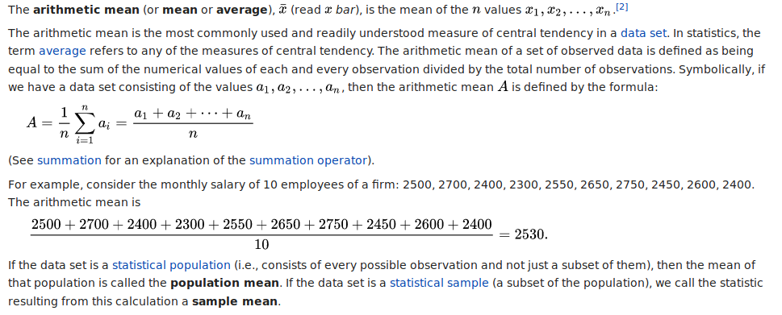

#### Median: (‘order statistics’)

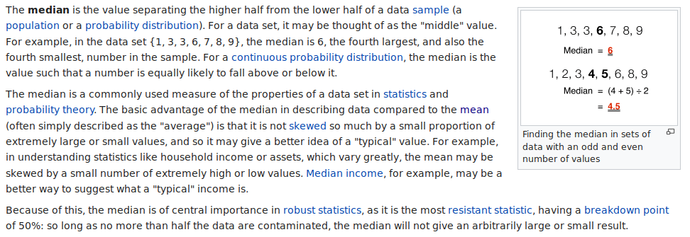

#### Mode

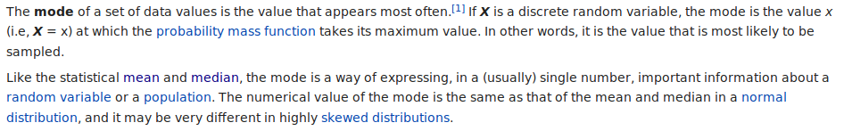

# Center of Some Distributions (‘population’)

- For normal (or Gaussian) distribution, with a symmetric, bell shape with one peak, the mean, median and mode are the same.

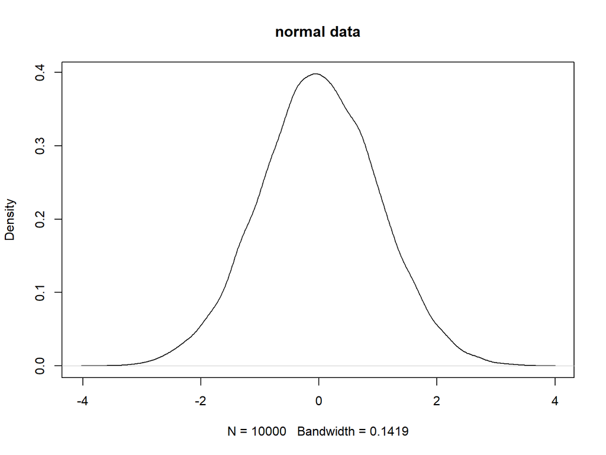

```r
set.seed(321)
NormalData<-  rnorm(10000) #standard N(0,1)
plot(density(NormalData), main='normal data')  # one center at 0
```

- For asymmetric distribution, the mean, median and mode may be all different.

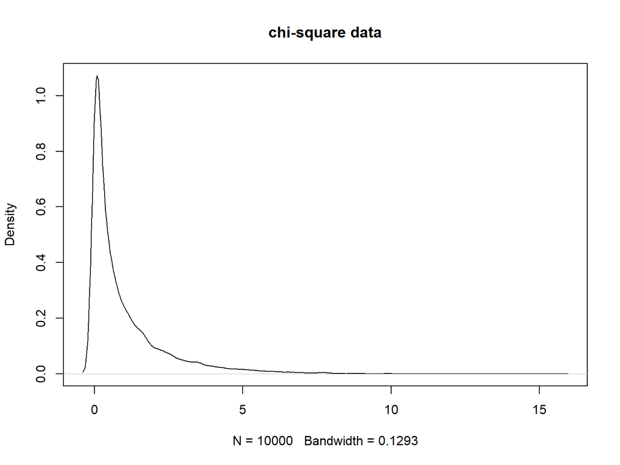

```r
set.seed(321)
ChiData<-  rchisq(10000, df=1) #chisquare distribution , right skewed
plot(density(ChiData), main='chi-square data')
```

# Data Examples (1)

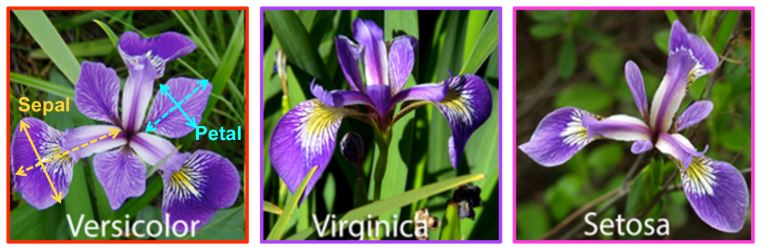

#### 1. Check the data description: (a commonly used data example)

```r
#?iris

# data  Structure
str(iris)
```

```
## 'data.frame':    150 obs. of  5 variables:
##  $ Sepal.Length: num  5.1 4.9 4.7 4.6 5 5.4 4.6 5 4.4 4.9 ...
##  $ Sepal.Width : num  3.5 3 3.2 3.1 3.6 3.9 3.4 3.4 2.9 3.1 ...
##  $ Petal.Length: num  1.4 1.4 1.3 1.5 1.4 1.7 1.4 1.5 1.4 1.5 ...
##  $ Petal.Width : num  0.2 0.2 0.2 0.2 0.2 0.4 0.3 0.2 0.2 0.1 ...
##  $ Species     : Factor w/ 3 levels "setosa","versicolor",..: 1 1 1 1 1 1 1 1 1 1 ...
```

```r
#show the first few lines of the transcriptome data
head(iris)
```

```
##   Sepal.Length Sepal.Width Petal.Length Petal.Width Species
## 1          5.1         3.5          1.4         0.2  setosa
## 2          4.9         3.0          1.4         0.2  setosa
## 3          4.7         3.2          1.3         0.2  setosa
## 4          4.6         3.1          1.5         0.2  setosa
## 5          5.0         3.6          1.4         0.2  setosa
## 6          5.4         3.9          1.7         0.4  setosa
```

```r
#tail(iris) #last 6

#show the sample names of the transcriptome data
names(iris)
```

```
## [1] "Sepal.Length" "Sepal.Width"  "Petal.Length" "Petal.Width"
## [5] "Species"
```

# Data Examples (2)

#### 2. Getting the mean, median and mode of one variable

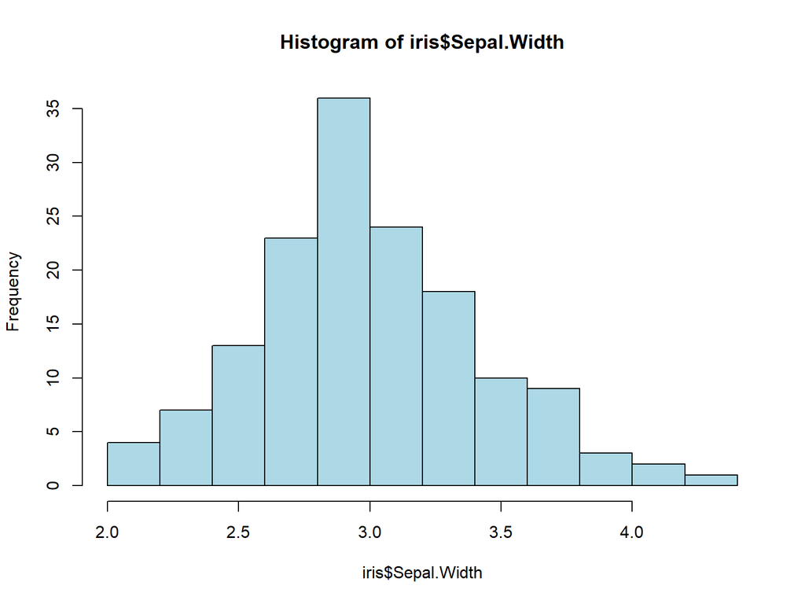

```r
# It is good idea to always plot the data to do some 'visual inspection' first
hist(iris$Sepal.Width, col='light blue')
```

```r
#mean
mean(iris$Sepal.Width)
```

```
## [1] 3.057333
```

```r
#median
median(iris$Sepal.Width)
```

```
## [1] 3
```

```r
#mode using mfv - most frequent value, part of modeest package
library(modeest)
mfv(iris$Sepal.Width)
```

```
## [1] 3
```

#### Note:

Sometimes, there are missing value, we use **na.rm=T** as an extra argument to removing missing at calculation.

# Try our randomly generated data

#### 1. Normal data (same mean/median)

```r
#set.seed(321) ;  NormalData<-  rnorm(10000) #standard N(0,1)
mean(NormalData)
```

```
## [1] 0.004038458
```

```r
median(NormalData)
```

```
## [1] -0.0002606666
```

#### 2. Chi-square data (different mean/median, mean is pulled to the skewed side)

```r
# set.seed(321); ChiData<-  rchisq(10000, df=1) #chisquare distribution , right skewed

mean(ChiData)
```

```
## [1] 0.988585
```

```r
median(ChiData)
```

```
## [1] 0.4480839
```

Note: If you have truly continuous data, or each discrete data points are different, there will be no unique or meaningfully ‘mode’.

# Measures of Data Spread and Variability (sec 2.2)

#### 1. Min , max and range

```r
#min, max, range
min(iris$Sepal.Width)
```

```
## [1] 2
```

```r
max(iris$Sepal.Width)
```

```
## [1] 4.4
```

```r
range(iris$Sepal.Width)
```

```
## [1] 2.0 4.4
```

#### 2. Variance = $E{(X-\mu)}^2$, and standard deviation, $\sigma= \sqrt{variance}$

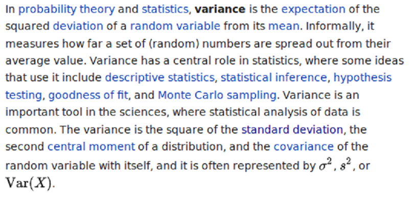

```r
#variance
var(iris$Sepal.Width)
```

```
## [1] 0.1899794
```

```r
var(iris$Petal.Width)
```

```
## [1] 0.5810063
```

```r
#standard deviation
sd(iris$Sepal.Width)
```

```
## [1] 0.4358663
```

```r
sd(iris$Petal.Width)
```

```
## [1] 0.7622377
```

#### 3. Coefficient of Variation (CV)

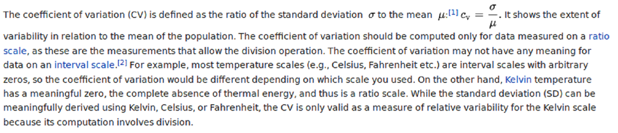

- CV is a relative measure of dispersion. Sometimes, inter-assay and intra-assay CV to check for precision and performance of the assay.

```r
#coefficient of variation
(sd(iris$Sepal.Width)/mean(iris$Sepal.Width))*100
```

```
## [1] 14.25642
```

```r
(sd(iris$Petal.Width)/mean(iris$Petal.Width))*100
```

```
## [1] 63.55511
```

#### 4. Standard Error or SEM, $SE= SD/\sqrt{n}$

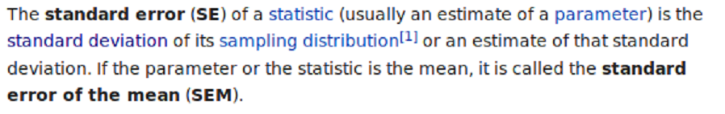

```r
(sd(iris$Sepal.Width)/(sqrt(length(iris$Sepal.Width))))
```

```
## [1] 0.03558833
```

```r
(sd(iris$Petal.Width)/(sqrt(length(iris$Petal.Width))))
```

```
## [1] 0.06223645
```

# Measures of Data Spread and Variability(2) (sec 2.2)

#### 5. Quantiles/Percentiles, quartiles (25%-Q1, median-Q2, 75%-Q3)

We commonly used Mean +/- SEM to summarize the variable if it is approximately normal or use Median (Interquartile Range, IQR, Q1 to Q3) to summarize the variable if it is skewed.

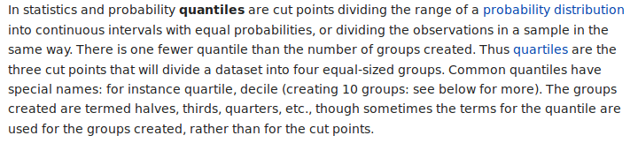

```r
#quantiles
quantile(iris$Sepal.Width)
```

```
##   0%  25%  50%  75% 100%
##  2.0  2.8  3.0  3.3  4.4
```

```r
quantile(iris$Sepal.Width, prob=c(1/3, 2/3)) #tercile
```

```
## 33.33333% 66.66667%
##       2.9       3.2
```

```r
#summary: R function to provide 6 summary stat for each numeric var and freq for categorical var,
summary(iris$Sepal.Width)
```

```
##    Min. 1st Qu.  Median    Mean 3rd Qu.    Max.
##   2.000   2.800   3.000   3.057   3.300   4.400
```

```r
#summary: apply to a data frame to summarize every variable
summary(iris)
```

```
##   Sepal.Length    Sepal.Width     Petal.Length    Petal.Width
##  Min.   :4.300   Min.   :2.000   Min.   :1.000   Min.   :0.100
##  1st Qu.:5.100   1st Qu.:2.800   1st Qu.:1.600   1st Qu.:0.300
##  Median :5.800   Median :3.000   Median :4.350   Median :1.300
##  Mean   :5.843   Mean   :3.057   Mean   :3.758   Mean   :1.199
##  3rd Qu.:6.400   3rd Qu.:3.300   3rd Qu.:5.100   3rd Qu.:1.800
##  Max.   :7.900   Max.   :4.400   Max.   :6.900   Max.   :2.500
##        Species
##  setosa    :50
##  versicolor:50
##  virginica :50
##
##
##
```

**We can apply summary in several subgroups:**

```r
by(iris$Sepal.Width, iris$Species, summary)
```

```
## iris$Species: setosa
##    Min. 1st Qu.  Median    Mean 3rd Qu.    Max.
##   2.300   3.200   3.400   3.428   3.675   4.400
## --------------------------------------------------------
## iris$Species: versicolor
##    Min. 1st Qu.  Median    Mean 3rd Qu.    Max.
##   2.000   2.525   2.800   2.770   3.000   3.400
## --------------------------------------------------------
## iris$Species: virginica
##    Min. 1st Qu.  Median    Mean 3rd Qu.    Max.
##   2.200   2.800   3.000   2.974   3.175   3.800
```

```r
by(iris$Sepal.Width, iris$Species, sd)
```

```
## iris$Species: setosa
## [1] 0.3790644
## --------------------------------------------------------
## iris$Species: versicolor
## [1] 0.3137983
## --------------------------------------------------------
## iris$Species: virginica
## [1] 0.3224966
```

#### Box-plot or Box-Whisker plot

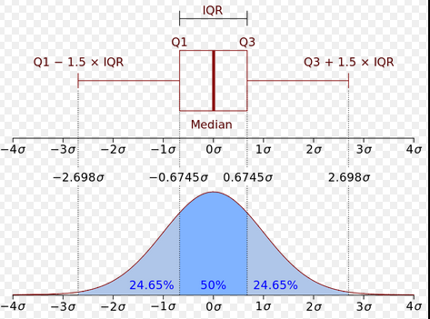

Note: It is useful to use boxplot to check the distribution of a variable : is it symmetric? Any outliers?

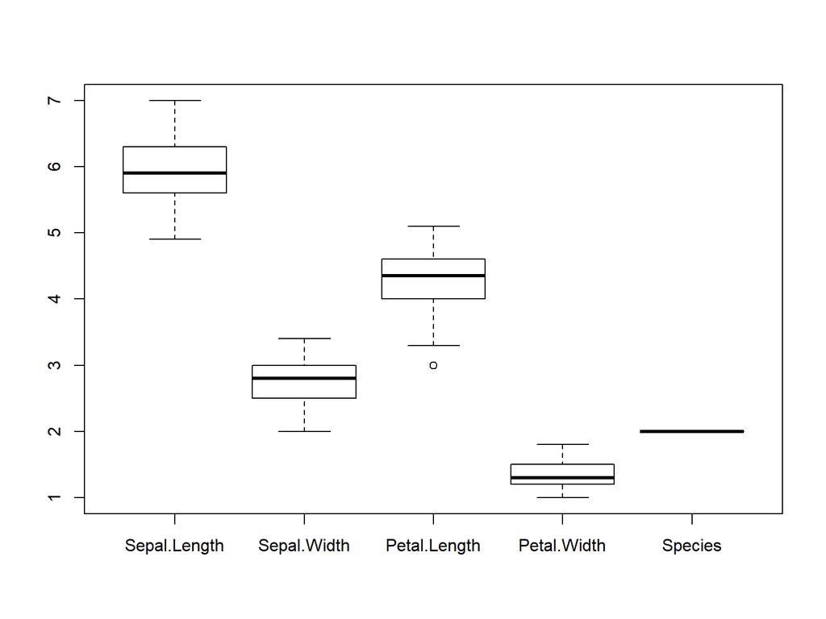

```r
#boxplot - This include the factor 'Species' var
boxplot(subset(iris,Species=='versicolor'))
```

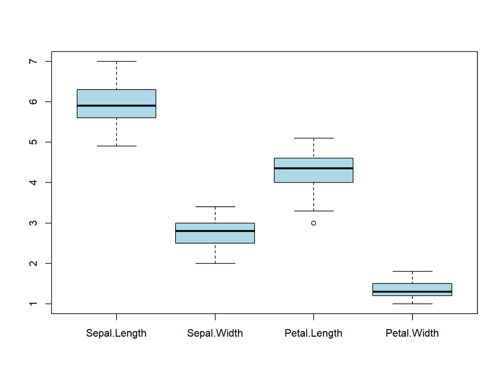

```r
# better way
boxplot(subset(iris,Species=='versicolor')[,1:4], col='lightblue')
```

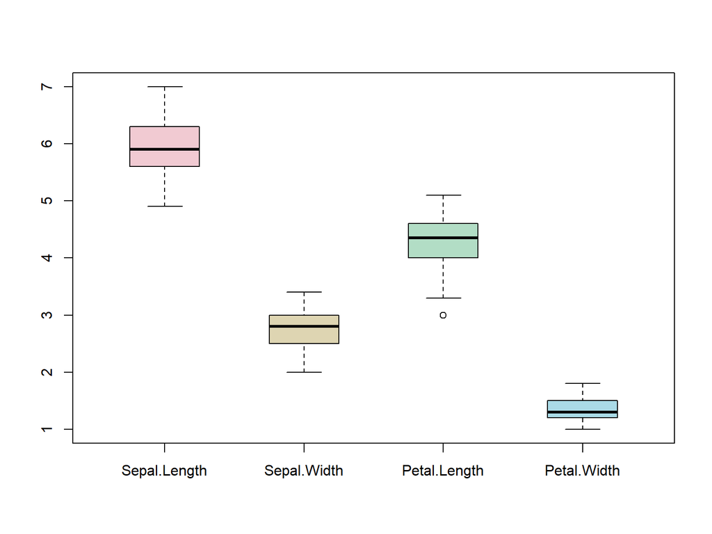

```r
library(colorspace)
boxplot(subset(iris,Species=='versicolor')[,1:4], col= rainbow_hcl(5, alpha=0.5), boxwex = 0.5)
```

# Descriptive stat for categorical variable

For binary or categorical variables, we are mostly interested in frequency and percentage , n (%).

```r
# n
table(iris$Species)
```

```
##
##     setosa versicolor  virginica
##         50         50         50
```

```r
#%
prop.table(table(iris$Species))
```

```
##
##     setosa versicolor  virginica
##  0.3333333  0.3333333  0.3333333
```

```r
#round off
round(prop.table(table(iris$Species))*100, 1)
```

```
##
##     setosa versicolor  virginica
##       33.3       33.3       33.3
```

# Common Data Distribution: (Sec 3)

There are many statistical distributions. We will discuss a few of common used ones today.

**Normal Distribution** is the most important distribution because

1. The fundamental central limit theorem: if you take sufficiently large independent random samples from the population, then the distribution of the sample means will be approximately normally distributed. This will hold true regardless of whether the source population is normal or skewed, continuous or discrete, provided the sample size is sufficiently large (usually n > 30).
2. Many statistical theories and tests are based on normal assumption. It is only characterized by two parameters.

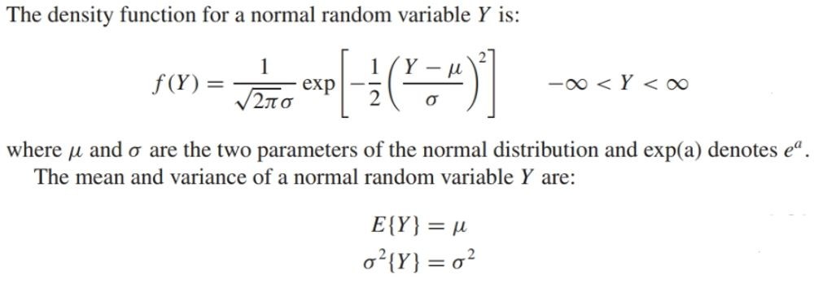

3. We can use **plot(density())** to check the shape of the distribution, use **qqnorm()** to compare with normal quantiles, or **Shapiro-Wilk Normality Test** to check normal assumption.

**Example**

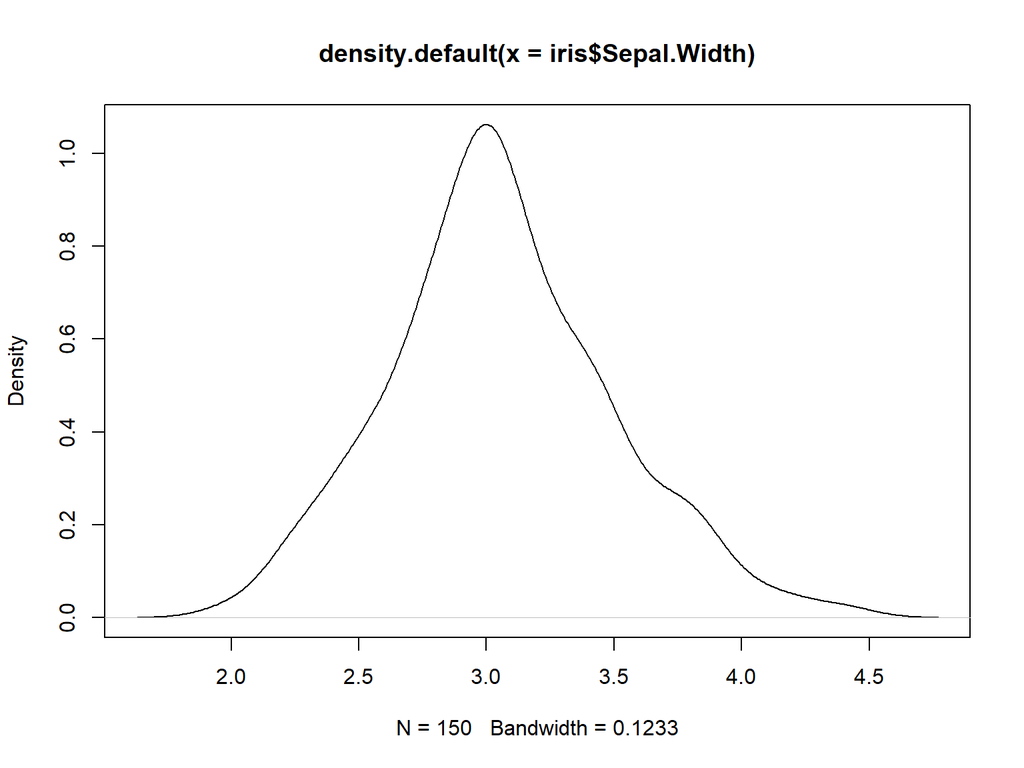

```r
# help("Distributions")

#visualizing data density distribution
plot(density(iris$Sepal.Width))
```

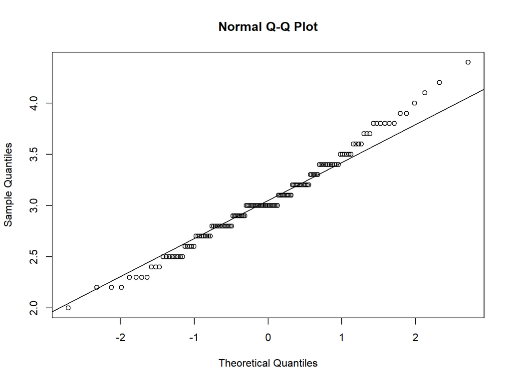

```r
qqnorm(iris$Sepal.Width)
qqline(iris$Sepal.Width)
```

```r
#testing for normality
#is the sepal width normally distributed ?
shapiro.test(iris$Sepal.Width)
```

```
##
##  Shapiro-Wilk normality test
##
## data:  iris$Sepal.Width
## W = 0.98492, p-value = 0.1012
```

Note: p-value=0.10 > 0.05, and we can’t reject the normality at the significance level of 0.05.

4. Assuming the underlying distribution is normal for **Sepal.Width**, we can compute certain probability of an event. **pnorm()** calculates the probability of a given normal distribution.

```r
c(mean= mean(iris$Sepal.Width ),sd= sd(iris$Sepal.Width ))
```

```
##      mean        sd
## 3.0573333 0.4358663
```

```r
#calculate and use the mean and sd of Sepal.Width
#what is the probability of observing a sepal width less than 2  : Pr(Y<2)
# this is very small since 2 is ~ 2.4 SD away from the mean.
pnorm(2,mean=3.057,sd=0.4358)
```

```
## [1] 0.007645248
```

```r
#what is the probability of observing a sepal width 2 or more:  : Pr(Y>=2)=1- Pr(Y<2)
pnorm(2,mean=3.057,sd=0.4358, lower.tail = FALSE)
```

```
## [1] 0.9923548
```

# Other Common Continuous Distributions

Later we will discuss some statistical tests: chi-square test, t-test and F-tests based on these distributions (all related to normal variables).

#### 2. Chi-square distribution, df

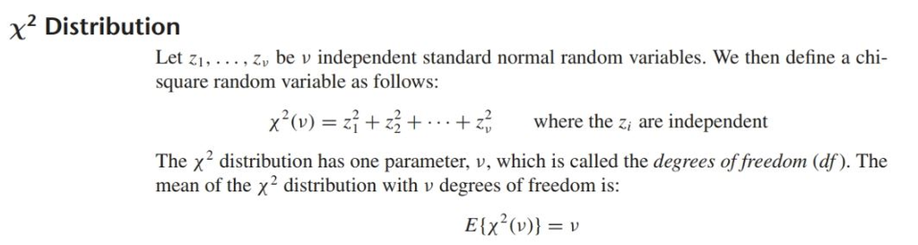

#### 3. t-distribution, df (symmetric, long-tails than standard normal).

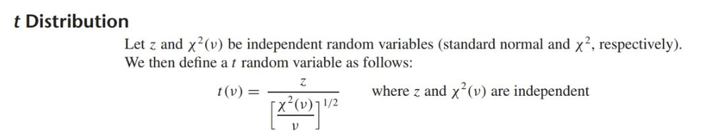

#### 4. F-distribution, df1, df2

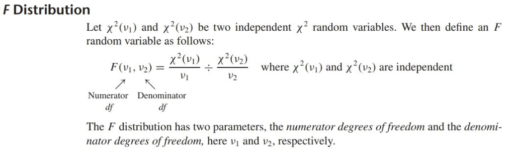

# Discrete Distributions

**Binomial Distribution** is a common used distribution for discrete variable. A variable $X$ is considered binomially distributed, if $X$ = the number of success of $n$ independent trials where each trial consists of two possible results, with a fixed probability of success, e.g. flipping a coin 20 times.

#### Example

Our example data shows that 78% of the students who take the AP biology test, pass the exam. If 12 new students take this test, what is the probability that exactly 8 of them will pass the test ?

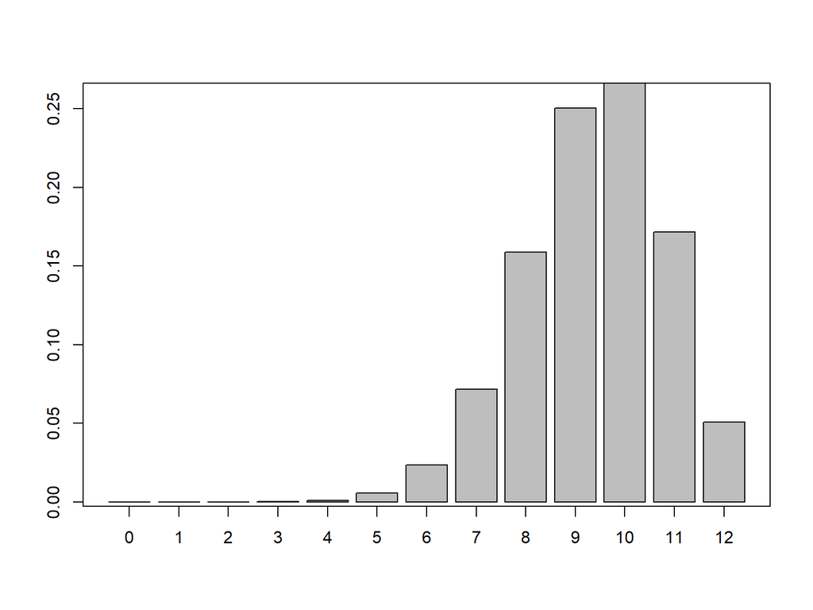

```r
#?dbinom
#data visualization
#1. calculate the probability distribution for all possible outcomes

passprob=dbinom(0:12,size=12,prob=0.78)

#visualize the probability distribution
barplot(passprob)
axis(1, at=seq(0.7, 15.1, 1.2),  labels=0:12)
box()
```

```r
#probability =Pr(X= 8| N=12, p=.78)
dbinom(8,12, 0.78)
```

```
## [1] 0.158874
```

```r
#If 12 new students take this test, what is the probability that at least 8 of them will pass the test ? = Pr(X>=8)
pbinom(7, size=12, prob = 0.78, lower.tail = FALSE)
```

```
## [1] 0.897864
```

```r
#If change p=0.5 ?
pbinom(7, size=12, prob = 0.5, lower.tail = FALSE)
```

```
## [1] 0.1938477
```

**Note**:

Distribution theories are more useful in the context of statistical inference. Often, people apply the statistical tests without knowing or checking the underlying distribution assumption, or apply the wrong test when the asumptions are not met. We will discuss more tomorrow with examples.

# Data transformation (Sec 4)

We often need to create new variables or apply certain transformation (e.g. log-transformation for skewed variable) to our data set This can be done by the traditional way or use the new **tidyverse** package.

```r
Rpackage= "tidyverse"
if (! Rpackage %in% installed.packages()) install.packages(Rpackage)
library(tidyverse)
```

Some examples below are based on a online book **R for Data Science**, by Garrett Grolemund and Hadley Wickham, from RStudio, also the authors of many useful new R packages.

Their data exploration flowchart is

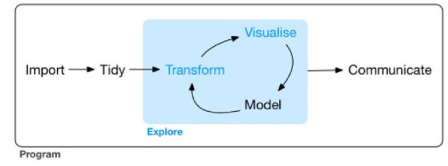

# 3.1 Check data.

This data frame contains all 336,776 flights that departed from New York City in 2013.

```r
Rpackage= "nycflights13"
if (! Rpackage %in% installed.packages()) install.packages(nycflights13)

library('nycflights13')

#? flights
data(flights)
str(flights)
```

```
## Classes 'tbl_df', 'tbl' and 'data.frame':    336776 obs. of  19 variables:
##  $ year          : int  2013 2013 2013 2013 2013 2013 2013 2013 2013 2013 ...
##  $ month         : int  1 1 1 1 1 1 1 1 1 1 ...
##  $ day           : int  1 1 1 1 1 1 1 1 1 1 ...
##  $ dep_time      : int  517 533 542 544 554 554 555 557 557 558 ...
##  $ sched_dep_time: int  515 529 540 545 600 558 600 600 600 600 ...
##  $ dep_delay     : num  2 4 2 -1 -6 -4 -5 -3 -3 -2 ...
##  $ arr_time      : int  830 850 923 1004 812 740 913 709 838 753 ...
##  $ sched_arr_time: int  819 830 850 1022 837 728 854 723 846 745 ...
##  $ arr_delay     : num  11 20 33 -18 -25 12 19 -14 -8 8 ...
##  $ carrier       : chr  "UA" "UA" "AA" "B6" ...
##  $ flight        : int  1545 1714 1141 725 461 1696 507 5708 79 301 ...
##  $ tailnum       : chr  "N14228" "N24211" "N619AA" "N804JB" ...
##  $ origin        : chr  "EWR" "LGA" "JFK" "JFK" ...
##  $ dest          : chr  "IAH" "IAH" "MIA" "BQN" ...
##  $ air_time      : num  227 227 160 183 116 150 158 53 140 138 ...
##  $ distance      : num  1400 1416 1089 1576 762 ...
##  $ hour          : num  5 5 5 5 6 5 6 6 6 6 ...
##  $ minute        : num  15 29 40 45 0 58 0 0 0 0 ...
##  $ time_hour     : POSIXct, format: "2013-01-01 05:00:00" "2013-01-01 05:00:00" ...
```

```r
#head(flights,3)
```

# 3.2 basic data transformation steps using **dplyr**

### 3.2.1 Pick observations by their values: **filter()**

```r
# pick all flights on certain date, note "==" for comparison, "=" for assignment

Dec25 =  filter(flights, month == 12, day == 25)
Dec25
```

```
## # A tibble: 719 x 19
##     year month   day dep_time sched_dep_time dep_delay arr_time
##    <int> <int> <int>    <int>          <int>     <dbl>    <int>
##  1  2013    12    25      456            500        -4      649
##  2  2013    12    25      524            515         9      805
##  3  2013    12    25      542            540         2      832
##  4  2013    12    25      546            550        -4     1022
##  5  2013    12    25      556            600        -4      730
##  6  2013    12    25      557            600        -3      743
##  7  2013    12    25      557            600        -3      818
##  8  2013    12    25      559            600        -1      855
##  9  2013    12    25      559            600        -1      849
## 10  2013    12    25      600            600         0      850
## # ... with 709 more rows, and 12 more variables: sched_arr_time <int>,
## #   arr_delay <dbl>, carrier <chr>, flight <int>, tailnum <chr>,
## #   origin <chr>, dest <chr>, air_time <dbl>, distance <dbl>, hour <dbl>,
## #   minute <dbl>, time_hour <dttm>
```

# 3.2.2 Reorder data: **arrange()**

It takes a data frame and a set of column names to order by. If you provide more than one column name, each additional column will be used to break ties in the values of preceding columns:

```r
# Arrange rows and order by
arrange(flights, year, month, day)
```

```
## # A tibble: 336,776 x 19
##     year month   day dep_time sched_dep_time dep_delay arr_time
##    <int> <int> <int>    <int>          <int>     <dbl>    <int>
##  1  2013     1     1      517            515         2      830
##  2  2013     1     1      533            529         4      850
##  3  2013     1     1      542            540         2      923
##  4  2013     1     1      544            545        -1     1004
##  5  2013     1     1      554            600        -6      812
##  6  2013     1     1      554            558        -4      740
##  7  2013     1     1      555            600        -5      913
##  8  2013     1     1      557            600        -3      709
##  9  2013     1     1      557            600        -3      838
## 10  2013     1     1      558            600        -2      753
## # ... with 336,766 more rows, and 12 more variables: sched_arr_time <int>,
## #   arr_delay <dbl>, carrier <chr>, flight <int>, tailnum <chr>,
## #   origin <chr>, dest <chr>, air_time <dbl>, distance <dbl>, hour <dbl>,
## #   minute <dbl>, time_hour <dttm>
```

```r
# use desc() to re-order by a column in descending order:
# Missing values are always sorted at the end:

arrange(flights, desc(dep_time))
```

```
## # A tibble: 336,776 x 19
##     year month   day dep_time sched_dep_time dep_delay arr_time
##    <int> <int> <int>    <int>          <int>     <dbl>    <int>
##  1  2013    10    30     2400           2359         1      327
##  2  2013    11    27     2400           2359         1      515
##  3  2013    12     5     2400           2359         1      427
##  4  2013    12     9     2400           2359         1      432
##  5  2013    12     9     2400           2250        70       59
##  6  2013    12    13     2400           2359         1      432
##  7  2013    12    19     2400           2359         1      434
##  8  2013    12    29     2400           1700       420      302
##  9  2013     2     7     2400           2359         1      432
## 10  2013     2     7     2400           2359         1      443
## # ... with 336,766 more rows, and 12 more variables: sched_arr_time <int>,
## #   arr_delay <dbl>, carrier <chr>, flight <int>, tailnum <chr>,
## #   origin <chr>, dest <chr>, air_time <dbl>, distance <dbl>, hour <dbl>,
## #   minute <dbl>, time_hour <dttm>
```

# 3.2.3 Pick variables by their names: **select()**

If you have a large data with lots of columns/variables, you can use select() to subset and select certain columns.

```r
# Select columns by name
select(flights, year, month, day)
```

```
## # A tibble: 336,776 x 3
##     year month   day
##    <int> <int> <int>
##  1  2013     1     1
##  2  2013     1     1
##  3  2013     1     1
##  4  2013     1     1
##  5  2013     1     1
##  6  2013     1     1
##  7  2013     1     1
##  8  2013     1     1
##  9  2013     1     1
## 10  2013     1     1
## # ... with 336,766 more rows
```

```r
# select a number of variables between the two specified ones: inclusive
select(flights, year:sched_dep_time)
```

```
## # A tibble: 336,776 x 5
##     year month   day dep_time sched_dep_time
##    <int> <int> <int>    <int>          <int>
##  1  2013     1     1      517            515
##  2  2013     1     1      533            529
##  3  2013     1     1      542            540
##  4  2013     1     1      544            545
##  5  2013     1     1      554            600
##  6  2013     1     1      554            558
##  7  2013     1     1      555            600
##  8  2013     1     1      557            600
##  9  2013     1     1      557            600
## 10  2013     1     1      558            600
## # ... with 336,766 more rows
```

```r
# move some variables to the start of the data frame
select(flights, time_hour, air_time, everything())
```

```
## # A tibble: 336,776 x 19
##    time_hour           air_time  year month   day dep_time sched_dep_time
##    <dttm>                 <dbl> <int> <int> <int>    <int>          <int>
##  1 2013-01-01 05:00:00      227  2013     1     1      517            515
##  2 2013-01-01 05:00:00      227  2013     1     1      533            529
##  3 2013-01-01 05:00:00      160  2013     1     1      542            540
##  4 2013-01-01 05:00:00      183  2013     1     1      544            545
##  5 2013-01-01 06:00:00      116  2013     1     1      554            600
##  6 2013-01-01 05:00:00      150  2013     1     1      554            558
##  7 2013-01-01 06:00:00      158  2013     1     1      555            600
##  8 2013-01-01 06:00:00       53  2013     1     1      557            600
##  9 2013-01-01 06:00:00      140  2013     1     1      557            600
## 10 2013-01-01 06:00:00      138  2013     1     1      558            600
## # ... with 336,766 more rows, and 12 more variables: dep_delay <dbl>,
## #   arr_time <int>, sched_arr_time <int>, arr_delay <dbl>, carrier <chr>,
## #   flight <int>, tailnum <chr>, origin <chr>, dest <chr>, distance <dbl>,
## #   hour <dbl>, minute <dbl>
```

Note. select() drops those variables not explicitly mentioned, but rename() only renames variables and keep other variables the same.

```r
flights= rename(flights, tail_num = tailnum)
#view(flights)
```

# 3.2.4 Create new variables using existing variables: **mutate()**

It’s often useful to add new columns that are functions of existing columns, mutate() always adds new columns at the end of your dataset. Remember in RStudio, the easiest way to see all the columns is View(). Note that you can use to columns that you’ve just created in mutate.

```r
# select certain colmns
flights_sml <- select(flights,
  year:day,
  ends_with("delay"),
  distance,
  air_time
)

# adding new variables
mutate(flights_sml,
  gain = dep_delay - arr_delay,
  speed = distance / air_time*60,
  hours = air_time / 60,
  gain_per_hour = gain / hours,
  log_distance= log(distance)
)
```

```
## # A tibble: 336,776 x 12
##     year month   day dep_delay arr_delay distance air_time  gain speed
##    <int> <int> <int>     <dbl>     <dbl>    <dbl>    <dbl> <dbl> <dbl>
##  1  2013     1     1         2        11     1400      227    -9  370.
##  2  2013     1     1         4        20     1416      227   -16  374.
##  3  2013     1     1         2        33     1089      160   -31  408.
##  4  2013     1     1        -1       -18     1576      183    17  517.
##  5  2013     1     1        -6       -25      762      116    19  394.
##  6  2013     1     1        -4        12      719      150   -16  288.
##  7  2013     1     1        -5        19     1065      158   -24  404.
##  8  2013     1     1        -3       -14      229       53    11  259.
##  9  2013     1     1        -3        -8      944      140     5  405.
## 10  2013     1     1        -2         8      733      138   -10  319.
## # ... with 336,766 more rows, and 3 more variables: hours <dbl>,
## #   gain_per_hour <dbl>, log_distance <dbl>
```

# 3.2.5 Generate data summary: **summarise()**

summarise() is to summarize the observation with summary statistics.

```r
# Summary one variable
summarise(flights, mean_delay = mean(dep_delay, na.rm = TRUE),
           sd_delay = sd(dep_delay, na.rm = TRUE),
           median_delay = median(dep_delay, na.rm = TRUE) )
```

```
## # A tibble: 1 x 3
##   mean_delay sd_delay median_delay
##        <dbl>    <dbl>        <dbl>
## 1       12.6     40.2           -2
```

It is mostly useful to pair it with group_by(). So for the each subgroup defined by groupby, the summary statistics are provided.

```r
# by destination
table(flights$dest)
```

```
##
##   ABQ   ACK   ALB   ANC   ATL   AUS   AVL   BDL   BGR   BHM   BNA   BOS
##   254   265   439     8 17215  2439   275   443   375   297  6333 15508
##   BQN   BTV   BUF   BUR   BWI   BZN   CAE   CAK   CHO   CHS   CLE   CLT
##   896  2589  4681   371  1781    36   116   864    52  2884  4573 14064
##   CMH   CRW   CVG   DAY   DCA   DEN   DFW   DSM   DTW   EGE   EYW   FLL
##  3524   138  3941  1525  9705  7266  8738   569  9384   213    17 12055
##   GRR   GSO   GSP   HDN   HNL   HOU   IAD   IAH   ILM   IND   JAC   JAX
##   765  1606   849    15   707  2115  5700  7198   110  2077    25  2720
##   LAS   LAX   LEX   LGA   LGB   MCI   MCO   MDW   MEM   MHT   MIA   MKE
##  5997 16174     1     1   668  2008 14082  4113  1789  1009 11728  2802
##   MSN   MSP   MSY   MTJ   MVY   MYR   OAK   OKC   OMA   ORD   ORF   PBI
##   572  7185  3799    15   221    59   312   346   849 17283  1536  6554
##   PDX   PHL   PHX   PIT   PSE   PSP   PVD   PWM   RDU   RIC   ROC   RSW
##  1354  1632  4656  2875   365    19   376  2352  8163  2454  2416  3537
##   SAN   SAT   SAV   SBN   SDF   SEA   SFO   SJC   SJU   SLC   SMF   SNA
##  2737   686   804    10  1157  3923 13331   329  5819  2467   284   825
##   SRQ   STL   STT   SYR   TPA   TUL   TVC   TYS   XNA
##  1211  4339   522  1761  7466   315   101   631  1036
```

```r
by_dest <- group_by(flights, dest)
    delay <- summarise(by_dest,
                       count = n(),
                       dist = mean(distance, na.rm = TRUE),
                       delay = mean(arr_delay, na.rm = TRUE)
    )
(delay <- filter(delay, count > 20, dest != "HNL"))
```

```
## # A tibble: 96 x 4
##    dest  count  dist delay
##    <chr> <int> <dbl> <dbl>
##  1 ABQ     254 1826   4.38
##  2 ACK     265  199   4.85
##  3 ALB     439  143  14.4
##  4 ATL   17215  757. 11.3
##  5 AUS    2439 1514.  6.02
##  6 AVL     275  584.  8.00
##  7 BDL     443  116   7.05
##  8 BGR     375  378   8.03
##  9 BHM     297  866. 16.9
## 10 BNA    6333  758. 11.8
## # ... with 86 more rows
```

# 3.2.6 Put everything together with a pipe operator

The pip operator,%>%, takes the output of one statement and makes it the input of the next statement. The above code can be shorted with pip analysis to avoid naming new variables each time.

```r
 delays <- flights %>%
      group_by(dest) %>%
      summarise(
        count = n(),
        dist = mean(distance, na.rm = TRUE),
        delay = mean(arr_delay, na.rm = TRUE)
      ) %>%
      filter(count > 20, dest != "HNL")
delays
```

```
## # A tibble: 96 x 4
##    dest  count  dist delay
##    <chr> <int> <dbl> <dbl>
##  1 ABQ     254 1826   4.38
##  2 ACK     265  199   4.85
##  3 ALB     439  143  14.4
##  4 ATL   17215  757. 11.3
##  5 AUS    2439 1514.  6.02
##  6 AVL     275  584.  8.00
##  7 BDL     443  116   7.05
##  8 BGR     375  378   8.03
##  9 BHM     297  866. 16.9
## 10 BNA    6333  758. 11.8
## # ... with 86 more rows
```

# 3.2.6 Exercises (20 mins)

1. Find all flights that
- Had an arrival delay of two or more hours
- Flew to Houston (HOU)
- Were operated by United or Southwest?
2. Sort flights to find the most delayed flights.
3. select dep_time, dep_delay, arr_time, and arr_delay from flights.